I'm happy to announce that *[R Programming for Data Science](http://leanpub.com/rprogramming?utm_source=coursera&utm_medium=CourseraEmail&utm_campaign=Coursera)* is available through Leanpub. This e-book is specifically designed for use with this course and compiles together all of lecture notes for the course in one place. I think you'll find it useful both for completing this course and for completing the rest of the Data Science Specialization. In addition to allowing you to have all the lecture content in one place, the e-book is a way for you to access the course materials after the class has finished. If you want, printed paper copies of the book are [available from Lulu](http://www.lulu.com/shop/roger-peng/r-programming-for-data-science/paperback/product-22280814.html) .

R Programming for Data Science is available in epub (iBooks), mobi (Kindle), and PDF (everything else) formats and so is viewable on just about any computer, tablet, or phone. If you get the book now, you will be entitled to free updates in the future (and there will likely be updates).

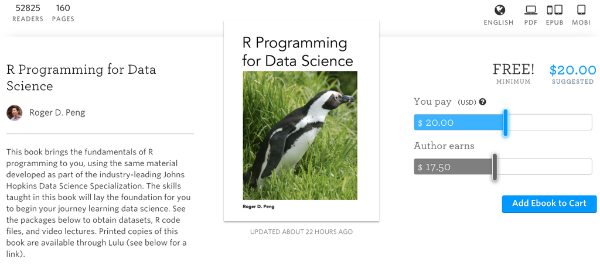

In addition to the lecture notes, a compilation of the key lecture videos themselves is available from the Apple iBooks Store via the *[R Programming Course Companion](http://apple.co/1AAfjiY)* .